# Empirical Exercises 4.2

Zheng Tian

This file include answers and R codes for completing Empirical Exercise 4.2 in Introduction to Econometrics (3rd edition) by Stock and Watson.

# Reading the Data

The first step is to read the data file into R. The data files for this problem are `TeachingRatings.dta` and `TeachingRatings.xls`, accompanied by a descriptive file `TeachingRatings_Description.pdf`.

- Read the STATA file

```r
library(foreign)
teachingdata <- read.dta("TeachingRatings.dta")
```

- Upon reading the data, we can take a glimpse on the data. Use `head` or `tail` to look at the first or last few observations

```r
head(teachingdata)
```

```
##   minority age female onecredit     beauty course_eval intro nnenglish
## 1        1  36      1         0  0.2899157         4.3     0         0
## 2        0  59      0         0 -0.7377322         4.5     0         0
## 3        0  51      0         0 -0.5719836         3.7     0         0
## 4        0  40      1         0 -0.6779634         4.3     0         0
## 5        0  31      1         0  1.5097942         4.4     0         0
## 6        0  62      0         0  0.5885687         4.2     0         0
```

# Summary Statistics

We get the summary statistics of the variables used in the analysis, which is `course_eval` and `beauty`

```r
df <- teachingdata[c("course_eval", "beauty")]
sumdf <- summary(df); sumdf
```

```
##   course_eval        beauty
##  Min.   :2.100   Min.   :-1.45049
##  1st Qu.:3.600   1st Qu.:-0.65627
##  Median :4.000   Median :-0.06801
##  Mean   :3.998   Mean   : 0.00000
##  3rd Qu.:4.400   3rd Qu.: 0.54560
##  Max.   :5.000   Max.   : 1.97002
```

We can create a table that looks professional using `stargazer()`.

```r
library(stargazer)
stargazer(df, type = "html", header = FALSE,
          title = "Summary Statistics", label = "tab:sum-stats")
```

**Summary Statistics**

| Statistic | N | Mean | St. Dev. | Min | Max |
| --- | --- | --- | --- | --- | --- |
| course_eval | 463 | 3.998 | 0.555 | 2.100 | 5.000 |
| beauty | 463 | 0.00000 | 0.789 | -1.450 | 1.970 |

# Scatterplot

We can make scatterplot using the `plot` function.

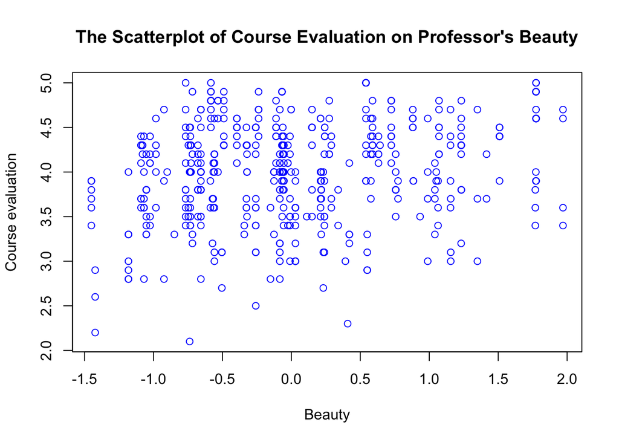

```r
  teaching.formula <- course_eval ~ beauty
  plot(teaching.formula, data = teachingdata,
     main = "The Scatterplot of Course Evaluation on Professor's Beauty",
     xlab="Beauty", ylab = "Course evaluation", col = "blue")
```

# Regression

Now let’s estimate the regression model. The results is reported in Table

```r
# run a regression of course evaluation on professor's beauty
teaching.ols <- lm(teaching.formula, data = teachingdata)

# create the table
stargazer(teaching.ols, type = "html", covariate.labels = c("Beauty"), dep.var.labels = c("Course Evaluations"),
    title = "The OLS Estimation of the Regression of Course Evaluation on Beauty",
    label = "tab:ols-1", single.row = TRUE, omit.stat = c("adj.rsq", "f"))
```

**The OLS Estimation of the Regression of Course Evaluation on Beauty**

|  | *Dependent variable:* |
| --- | --- |
|  | Course Evaluations |
| Beauty | 0.133*** (0.032) |
| Constant | 3.998*** (0.025) |
| Observations | 463 |
| R<sup>2</sup> | 0.036 |
| Residual Std. Error | 0.545 (df = 461) |
| *Note:* | p<0.1; p<0.05; p<0.01 |

# Answers to the questions

1. The scatterplot is the figure shown above. There appears to be a weak positive relationship between course evaluation and the beauty index.
2. The estimation results are reported in the table above .

We use the following code the get the answers to (b) and (c).

```r
beauty.watson <- mean(teachingdata$beauty)
beauty.stock <- mean(teachingdata$beauty) + sd(teachingdata$beauty)
ave.courseval <- mean(teachingdata$course_eval)

# do prediction step by step
b0 <- teaching.ols$coef[1]
b1 <- teaching.ols$coef[2]
courseval.predict <- b0 + b1 * c(beauty.watson, beauty.stock)
names(courseval.predict) <- c("waston", "stock")
```

3. The beauty indices for Professors Stock and Watson are 0.7886 (one standard deviation) and 0 (sample average). Thus, the predicted course evaluations for Professors Stock and Watson are 4.1032 and 3.9983, respectively.

The following code is to answer (d)

```r
beauty.sd <- sd(teachingdata$beauty)
courseval.sd <- sd(teachingdata$course_eval)
delta.courseval <- b1 * beauty.sd
```

The standard deviation of course evaluation is 0.5549, and the standard deviation of beauty is 0.7886. A one-standard-deviation increase in beauty is expected to increase course evaluation by 0.1049, or 0.19 of standard deviation of course evaluations. The effect is small.

```r
rsq <- summary(teaching.ols)$r.squared
```

The regression R<sup>2</sup> is 0.0357, so that *Beauty* explains only 3.6 percent of the variance in course evaluations.